# W6：統計圖表——先看圖，再看數字

心理教育統計 2026

授課教師：陳紹慶 | e-mail: csc2009@mail.tcu.edu.tw

2026/03/30

# 本週學習目標

## 學習成效指標

**認知規範**：

1. 理解常用統計圖的敘事功能
2. 掌握*視覺化*與*數值化*描述統計的對應關係
3. 學會選擇適合分析目標的圖表

**實作重點**：

1. 使用 jamovi 模組製作專業圖表
2. 識別並標註離群值
3. 匯出圖表至 Word 報告並撰寫 APA 格式圖表說明

## 對應教材

- 《用 jamovi 上手統計學》
  - [第 5 章：繪製統計圖](https://scgeeker.github.io/lsj-book-zh_tw/05-Drawing-graphs.html)

**簡報示範資料**：電子書範例 `anscombesquartet`,`aflsmall_margins`

**作業資料**：W04 清理後的個人化資料（Total_Score）

# Part 1：為何「先看圖」？🧠👨‍💻

### Anscombe’s Quartet：統計幻覺

> **四組資料，完全相同的統計數值，完全不同的故事**

| 統計量 | 四組資料的數值 |
| --- | --- |
| Mean X | 9.0 |
| Mean Y | 7.5 |
| SD X | 3.3 |
| SD Y | 2.0 |
| Correlation | 0.816 |

**重點**：如果只看數字，你會以為四組資料完全相同！

## 用圖表點破幻覺

Anscombe’s Quartet 的[四組散佈圖](https://upload.wikimedia.org/wikipedia/commons/e/ec/Anscombe%27s_quartet_3.svg)

```
左上: 線性關係
右上: 非線性關係（拋物線）
左下: 線性關係 + 一個離群值
右下: 垂直資料 + 一個極端值
```

**警告**：統計數值與資料結構沒有絕對關係！

## 資料視覺化的三大優點

1. **探索（Exploration）**：預覽資料分佈的模式與異常
2. **診斷（Diagnosis）**：檢查統計方法的**適用條件**是否成立
3. **溝通（Communication）**：展示發現
- **原則**：先看圖，確認數字有意義，再做推論

# Part 2：jamovi 2.7 新功能 - Plots Tab 🧠👨‍💻

## 過去的困擾

**jamovi 2.6 及之前**：

- 圖表「附屬」於統計分析模組（如 Descriptives）
- 無法獨立管理圖表
- 修改圖表需重新執行分析

## jamovi 2.7 的革新

**獨立的 Plots Tab**：

- 圖表成為「視覺化管理工具」
- 可以直接編輯圖表細節（標題、軸標籤、顏色）
- 除非有必要，不需使用統計分析模組製作圖表

**操作介面**：

```
切換Plot tab → 選擇要製作的Plot
```

## Plots Tab 介面

**主要功能**：

| Plot | 用途 | 適用變項尺度 |
| --- | --- | --- |
| Bar Plot | 柱狀圖 | 名義 |
| Box Plot | 箱形圖* | 次序, 連續 |
| Histogram | 直方圖* | 連續 |
| Scatter Plot | 散佈圖 | 次序, 連續 |
| Line Plot | 折線圖 | 連續 |
| Pareto Plot | 帕雷托圖？ | 次序, 連續 |

> **操作示範** `aflsmall_margins`
- 本次操作示範並列Plot Tab與描述統計模組的Plot呈現
- 作業的統計圖製作設定，請詳讀WORD檔案說明

# Part 3：直方圖（Histogram） 🧠👨‍💻

## 什麼是直方圖？

> **直方圖**：顯示資料分佈「形狀」的圖表

**關鍵元素**：

- **X 軸**：資料變項的數值範圍（如：分數 0-100）
- **Y 軸**：各數值出現的次數（頻率）
- **長條高度**：該區間內的資料筆數(n)或密度(density)

## 直方圖告訴我們什麼？

**形狀（Shape）**：

| 形狀 | 意義 |
| --- | --- |
| 對稱鐘形 | 常態分佈 |
| 右偏（長尾向右） | 少數高分，多數低分 |
| 左偏（長尾向左） | 多數高分，少數低分 |
| 雙峰 | 異質樣本混合 |

## 直方圖的製作要點

**關鍵設定**：

- 疊加常態密度曲線（Density）
- 選擇適當的組距（Bin Width）
- 清楚標示橫軸與縱軸

> **操作示範** `aflsmall_margins`

## 常見操作問題：組距（Bin Width）

**組距太寬**：失去細節，看不出分佈特徵

**組距太窄**：雜訊太多，看不出整體趨勢

**jamovi 預設**：自動選擇合適組距（通常可用）

## 直方圖 vs 偏態指數

**`aflsmall_margins`的數值診斷**：

| 偏態指數 | 直方圖形狀 |
| --- | --- |
| Skewness > 0 | 長尾向右，左側較高 |
| Skewness < 0 | 長尾向左，右側較高 |
| Skewness ≈ 0 | 對稱，接近鐘形 |

**實作練習**：運用自已的W4資料變項`Total_Score`，複習運用直方圖判斷資料分佈形態

# Part 4：箱形圖（Boxplot）🧠👨‍💻

## 什麼是箱形圖？

> **箱形圖**：顯示資料「五種指標」與「離群值」的圖表

**五種指標**：

- 最小值（Min）
- Q1（第 25 百分位數）
- 中位數（Median，Q2）
- Q3（第 75 百分位數）
- 最大值（Max）

## 箱形圖的結構

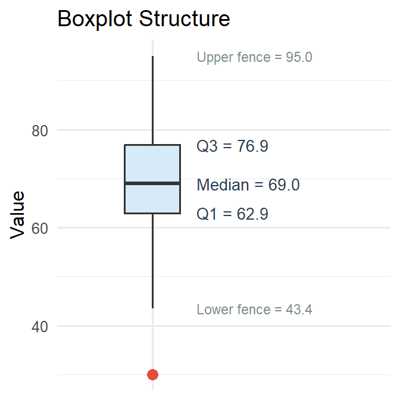

**箱子**：中間 50% 的資料（IQR）

**鬚線**：延伸至非離群值的最大/最小值

**圓點**：離群值（超出 1.5 × IQR）

## 箱形圖告訴我們什麼？

1. **中心位置**：中位數在哪裡？
2. **變異程度**：箱子越大，資料越分散
3. **偏態**：箱子不對稱 → 資料偏態
4. **離群值**：異常的極端值

## 箱形圖的解讀要點

**關鍵資訊**：

- 標註離群值編號（Label Outliers）
- 識別中位數、四分位距
- 檢查資料對稱性

## 離群值的處理

**發現離群值後，該怎麼辦？**

1. **檢查資料**：是真實數據還是測量錯誤？
2. **回顧 W4**：這些資料在清理時是否已處理？
3. **決策**：
   - 若為測量錯誤 → 刪除或修正
   - 若為真實極端值 → 保留，但使用穩健統計量（如中位數）

**LAB重點**：在報告中說明離群值的判斷與處理

# Part 4.5：小提琴圖（Violin Plot）🧠👨‍💻

## 什麼是小提琴圖？

> **小提琴圖**：結合箱形圖與直方密度圖的視覺化工具

**核心概念**：

- 外形：顯示資料的**密度分佈**（像旋轉 90° 的直方圖）
- 內部：包含**箱形圖**的五項指標
- 優點：同時看到「分佈形狀」與「統計摘要」

## 小提琴圖的結構

[figure not shown]

**關鍵元素**：

- **寬度**：該位置的資料密度（越寬 = 資料越多）
- **對稱軸**：通常為中位數
- **內部線條**：箱形圖的 Q1、Median、Q3

## 為什麼需要小提琴圖？

**箱形圖的限制 vs. 小提琴圖的好處**：

[figure not shown]

- 保留箱形圖的統計摘要
- 顯示完整的分佈形狀
- 目視識別雙峰、多峰、偏態

## 箱形圖 vs 小提琴圖

| 特性 | 箱形圖 | 小提琴圖 |
| --- | --- | --- |
| **顯示內容** | 五項指標 + 離群值 | 密度分佈 + 五項指標 |
| **分佈形狀** | ✗ 看不出 | ✓ 完整呈現 |
| **雙峰偵測** | ✗ 無法識別 | ✓ 清楚可見 |
| **離群值標註** | ✓ 清楚標示 | △ 較不明顯 |
| **學習曲線** | 容易理解 | 需要解釋 |

**建議**：兩者搭配使用，互補不足

## jamovi 操作：製作小提琴圖

1. **Analyses → Exploration → Plots**
2. 將 `aflsmall_margins` 拖曳至 Variables
3. 勾選 **Violin**
4. （選擇性）勾選 **Box plot**（在小提琴圖內疊加箱形圖）

**預期輸出**：

- 小提琴形狀顯示資料密度
- 內部顯示箱形圖的五項指標

## 小提琴圖的解讀

**觀察重點**：

1. **最寬的位置**：資料最集中的區域（眾數附近）
2. **形狀對稱性**：
   - 對稱 → 資料分佈均勻
   - 不對稱 → 偏態分佈
3. **是否有多個凸起**：雙峰或多峰分佈
4. **尾端延伸**：極端值的分佈

## 實例比較：三種圖表並列

**相同資料，三種呈現**：

| 圖表類型 | 優勢 | 適用情境 |
| --- | --- | --- |
| **直方圖** | 清楚的頻率分佈 | 初步探索資料 |
| **箱形圖** | 快速識別離群值 | 比較多組資料 |
| **小提琴圖** | 完整密度 + 統計摘要 | 深度分析單一變項 |

**實作建議**：三種圖表都做，報告選擇最能說故事的圖表

## 常見誤解：小提琴圖的「寬度」

**錯誤理解**：

> 「小提琴越寬，資料變異越大」

**正確理解**：

> 「寬度代表該位置的資料密度，與總變異無關」

**範例**：

- 窄小提琴 + 長尾 = 集中但有極端值
- 寬小提琴 = 資料在該區間密集

## 進階功能

**分組比較**：

- 將 `Group` 拖曳至 **Split By**
- 並列顯示不同組的箱形圖及小提琴圖
- 比較組間的分佈差異

**範例用途**：

- 比較男生 vs 女生的成績分佈
- 比較實驗組 vs 對照組的反應時間

# Part 5：圖表編輯課題🧠👨‍💻

## 問題：原始圖表不夠專業

**常見問題**：

- 變項名稱顯示原始代碼（如 `afl.margins`）
- 無圖表標題
- 軸標籤不清楚
- 無法直接用於報告或簡報

## 圖表整型工程

**使用 Plots Tab 修改**：

1. **標題（Title）**：加上有意義的標題
   - 例如：「AFL 比賽得分差距分佈」
2. **X 軸標籤（X-axis Label）**：
   - 從 `afl.margins` 改為「得分差距（分）」
3. **Y 軸標籤（Y-axis Label）**：
   - 從 `Density` 改為「密度」

## jamovi 操作：修改圖表標籤

1. 在 Plots 結果區，點選圖表
2. 點選右上角的 **⚙️（設定）**
3. 修改：
   - **Title**：輸入圖表標題
   - **X-axis label**：輸入 X 軸標籤
   - **Y-axis label**：輸入 Y 軸標籤
4. 套用修改

## 圖表匯出

**格式選擇**：

| 格式 | 用途 |
| --- | --- |
| PNG | 高解析度圖片，適合 Word或PPT 編輯 |
| PDF | 向量圖，適合印刷 |
| SVG | 可編輯向量圖，多數學術發表指定格式 |

**jamovi 操作**：

1. 右鍵點選圖表
2. 選擇 **Image** → **Export**
3. 選擇格式與存檔位置

## LAB重點：圖表匯出至 Word編輯

- 將圖表匯出為 **PNG**
- 以“插入檔案”編輯 **Word（DOCX）**報告
- 撰寫 **APA 格式圖表說明（Figure Note）**

**使用Word的理由？**

- 練習專業報告製作
- 學習圖文整合
- 培養視覺溝通能力

# Part 6：APA 格式圖表說明👨‍💻

❗簡報及報告範例並非你的資料❗

## 圖表說明的結構

**APA 格式圖表說明（Figure Note）**：

```
圖 1.
AFL 比賽得分差距分佈直方圖。

{Figure File}

註. 樣本共 N = 176 場比賽，得分差距範圍為 0–116 分，呈現明顯右偏分佈（Skewness = 0.78, SE = 0.18），顯示多數比賽差距偏小，少數比賽出現懸殊差距。疊加的曲線為理論機率分佈。
```

**結構**：

1. **圖號與標題**：  
   圖 1.  
   [標題]
2. **圖檔置放區**：手動置入圖檔；可渲染的程式碼或Latex腳本
3. **圖表元素說明**：樣本數、分佈特徵、曲線、標記等意義

## 圖表說明範例

**直方圖**：

```
Figure 1.
AFL 比賽得分差距分佈直方圖。

{Figure File}

註. 資料顯示右偏分佈（Skewness = 0.78），多數比賽差距偏小，少數比賽出現懸殊差距（最大值 116 分）。
```

## 圖表說明範例

**箱形圖**：

```
Figure 2.
AFL 比賽得分差距箱形圖。

{Figure File}

註. 中位數為 30.50 分，四分位距（IQR）為 37.75 分，顯示中間 50% 比賽的得分差距集中於相對較小的範圍，右偏的分佈特徵與圖 1 直方圖一致。
```

## 常見錯誤

| 錯誤 | 正確 |
| --- | --- |
| 圖號及標題同一行 | 分行呈現 |
| 標題過度白話「這是總分的圖」 | Figure 1. 學期總分分佈直方圖 |
| 圖表註釋無說明文字 | 圖表註釋必須包含解讀 |

# 本週作業

## W6 作業：視覺化診斷報告

**資料來源**：W4 的個人化資料（Total_Score）

**核心任務**：製作專業圖表並撰寫 APA 格式報告

## 任務一：製作直方圖

### Step 1：jamovi 操作

1. **Analyses → Exploration → Plots**
2. 將 `Total_Score` 拖曳至 **Variables**
3. 勾選 **Histogram**
4. 勾選 **Density**（疊加常態曲線）

**預期輸出**：

- 橫軸：Total_Score
- 縱軸：Density（密度）
- 疊加常態分佈曲線

### Step 2：圖表專業編輯

**使用 Plots Tab 修改標籤**：

**檢查清單**：

- 無底線或原始變項名（如 Total_Score）
- 標題清楚明確
- 軸標籤使用中文或正式名稱

### Step 3：匯出圖表

1. 右鍵點選圖表
2. 選擇 **Export → Image**
3. 格式：**PNG**
4. 存檔備用-> <學號>_<姓名>_histogram.png

### Step 4：APA 格式圖表範本

```
Figure 1
學期總分分佈直方圖。

{Figure file}

註. 樣本共 N = 100 人，總分呈現輕微正偏分佈（Skewness = 0.62），多數學生得分集中於 70-80 分。曲線為理論常態分佈。
```

**APA 格式要點**：

- **Figure X.** 圖標一行
- 簡潔標題及詳細解釋
- 註解以重要指標的說明統計圖的敘事

## 任務二：製作箱形圖

### Step 1：jamovi 操作

1. **Analyses → Exploration → Plots**
2. 將 `Total_Score` 拖曳至 **Variables**
3. 勾選 **Box Plot**
4. 勾選 **Label Outliers**（標註離群值編號）

**預期輸出**：

- 箱形圖顯示四分位數
- 離群值以 ID 標示

### Step 2：圖表專業化

**修改標籤**（同直方圖流程）：

- **Plot Title**：「量表計分箱形圖」
- **X-axis Title**：「總分」

### Step 3：匯出圖表

（同直方圖流程，匯出為 PNG 圖檔 -> <學號>_<姓名>_boxplot.png）

### Step 4：APA 格式圖表範本

```
Figure 2.
學期總分箱形圖。

{Figure file}

註. 中位數為 74.5 分，箱形顯示資料集中於 68-82 分區間。其中有 3 個離群值（ID: 5, 23, 87）。
```

**APA 格式要點**：

- 說明中位數與四分位距
- 明確指出離群值，提供後續處理參考

## 任務三：視覺化診斷寫作

**在 Word 報告第 3 頁回答**：

1. **一致性檢查**：
   - 直方圖的形狀是否與 W5 的偏態指數一致？
   - 若不一致，可能的原因是什麼？
2. **離群值診斷**：
   - 箱形圖識別出的離群值，在 W4 是否已處理？
   - 這些離群值是測量錯誤還是真實極端值？
3. **視覺 vs 數值**：
   - 圖表是否比單純的統計量更容易理解資料？
   - 舉例說明圖表揭示了哪些數字無法呈現的特徵。

## 選做加分：小提琴圖

**jamovi 操作**：

1. **Analyses → Exploration → Descriptives → Plots**
2. 將 `Total_Score` 拖曳至 Variables
3. 勾選 **Violin**
4. （選擇性）勾選 **Box plot**（疊加箱形圖）

**APA 格式圖表說明範例**：

```
Figure 3.
學期總分小提琴圖（含箱形圖）。

{Figure File}

註. 小提琴圖顯示資料的完整密度分佈，揭示雙峰特徵（68 分與 82 分處各有高峰），此特徵在直方圖中不易察覺。
```

**加分要點**：

- 以進行分組分析(自選獨變項敘事)
- 以小提琴圖說明不同分組的分佈特徵
- 說明與直方圖、箱形圖的差異

## 繳交項目

### 必繳檔案

1. **`學號_姓名_W6_Lab.omv`**
   - jamovi 檔案（含直方圖、箱形圖）
   - 圖表已完成專業化編輯
2. **`學號_姓名_W6_Report.docx`**
   - Word 報告（含圖表與 APA 格式說明）
3. **指定圖檔備份**
   - 直方圖、箱形圖PNG檔

**截止時間**：本次上課當天結束前

### 加分項目

- 見WORD加分區說明。有編輯內容，複評完成後手動評量。

## 評分標準

| 評分項目 | 配分 | 說明 |
| --- | --- | --- |
| **jamovi 操作** | 30% |  |
| - 直方圖製作 | 15% | 含常態曲線、標籤修改 |
| - 箱形圖製作 | 15% | 離群值標註、標籤修改 |
| **APA 格式寫作** | 45% |  |
| - Figure 1 說明 | 15% | 直方圖的完整 APA 格式描述 |
| - Figure 2 說明 | 15% | 箱形圖的完整 APA 格式描述 |
| - 視覺化診斷 | 15% | 回答三個診斷問題（Q1-Q3） |
| **圖表專業度** | 20% |  |
| - 無原始變項名 | 10% | 標籤已修改為正式名稱 |
| - 圖表匯出品質 | 10% | PNG 高解析度、清晰可讀 |
| **檔名與格式** | 5% | 檔名正確、Word 排版整齊 |

## 加分項目（最高 +10 分）

- 製作小提琴圖並深入分析：+5 分
- 三種圖表的比較分析：+5 分
- 得分可自選計入W02~W06任何一週的評分

# 重點回顧

## 本週關鍵概念

1. **先看圖，再看數字**：Anscombe’s Quartet 的教訓
2. **jamovi 2.7 新功能**：獨立的 Plots Tab
3. **直方圖**：顯示資料分佈形狀
4. **箱形圖**：識別離群值與中心位置
5. **小提琴圖**：結合密度分佈與統計摘要
6. **圖表選擇**：根據資料特性選擇適合的視覺化方式
7. **圖表專業化**：修改標籤、匯出至 Word
8. **APA 格式圖表說明**：Figure + 解讀文字

## 下週預告

**W7：機率與常態分佈**

- 理解常態分佈的特性
- 標準分數（Z-score）
- Q-Q Plot 診斷常態性

## Q&A

有任何問題嗎？